# Bioestadistica con R

Ing. Gorky Florez Castillo

Marzo 23, 2024

[figure not shown]

[figure not shown]

[figure not shown]

[figure not shown]

[figure not shown]

[figure not shown]

[figure not shown]

[figure not shown]

[figure not shown]

# 1 *Cargar los datos en R*

## 1.1 Datos de cargados manualmente

En R, cargar datos manualmente se refiere al proceso de introducir los datos directamente en el código del programa, en lugar de cargarlos desde un archivo externo. Esto se logra asignando los valores directamente a un objeto en R.

Por ejemplo, en el fragmento de código proporcionado, se crea un vector llamado “datos” que contiene una serie de valores numéricos. Cada valor separado por comas dentro de los paréntesis corresponde a un dato individual en el vector.

```r
datos <- c(41.59, 46.55, 73.38, 51.06, 51.94, 75.73, 56.91, 31.02, 39.70,
           43.32, 68.36, 55.40, 56.01, 51.66, 41.66, 76.80, 57.47, 20.50,
           60.52, 42.91, 33.98, 46.73, 34.61, 39.07, 40.62, 24.70, 62.57,
           52.30, 32.93, 68.81, 56.40, 45.57, 63.43, 63.17, 62.32, 60.33,
           58.31, 49.07, 45.41, 44.29, 39.58, 46.88, 31.02, 82.53, 68.12,
           33.15, 43.96, 43.00, 61.70, 48.75)
```

## 1.2 Cargar datos mediante URL

Cargar datos mediante URL en R implica acceder a conjuntos de datos alojados en servidores remotos a través de enlaces URL. Para esto, se utiliza la función read.table() o una función similar, pasando la URL como argumento al parámetro file. Es importante asegurarse de que la URL proporcione acceso directo al archivo de datos, y de que los datos estén en un formato compatible con la función de lectura que se está utilizando.

En el ejemplo proporcionado, se muestra cómo cargar datos desde una URL específica que apunta a un archivo de datos en formato tabular. La función read.table() se utiliza para leer el archivo y almacenar los datos en un objeto en R.

```r
url = 'https://raw.githubusercontent.com/fhernanb/datos/master/medidas_cuerpo'
datos <- read.table(file=url, header=T)
datos
```

| edad | peso | altura | sexo | muneca | biceps |
| --- | --- | --- | --- | --- | --- |
| 43 | 87.3 | 188.0 | Hombre | 12.2 | 35.8 |
| 65 | 80.0 | 174.0 | Hombre | 12.0 | 35.0 |
| 45 | 82.3 | 176.5 | Hombre | 11.2 | 38.5 |
| 37 | 73.6 | 180.3 | Hombre | 11.2 | 32.2 |
| 55 | 74.1 | 167.6 | Hombre | 11.8 | 32.9 |
| 33 | 85.9 | 188.0 | Hombre | 12.4 | 38.5 |
| 25 | 73.2 | 180.3 | Hombre | 10.6 | 38.3 |
| 35 | 76.3 | 167.6 | Hombre | 11.3 | 35.0 |
| 28 | 65.9 | 183.0 | Hombre | 10.2 | 32.1 |
| 26 | 90.9 | 183.0 | Hombre | 12.0 | 40.4 |

[output cut: 26 more lines]

[figure not shown]

En este caso, la URL apunta al archivo “medidas_cuerpo” alojado en GitHub. La opción header = TRUE se utiliza para indicar que la primera fila del archivo contiene los nombres de las columnas.

## 1.3 Cargar datos en formato txt

Cuando se trata de cargar datos en formato de archivo de texto (por ejemplo, .txt), R proporciona varias funciones, entre ellas read.table(), que permite leer datos tabulares desde un archivo de texto. La función read.table() es versátil y puede manejar una variedad de formatos de archivo de texto, incluidos aquellos con delimitadores específicos, como tabulaciones o comas.

Aquí tienes un ejemplo de cómo cargar datos desde un archivo de texto en formato .txt:

```r
panes  = read.table("data1.txt", header = T) #heade: los encabezados son los titulos
panes
```

| Subtipo | Genero | Expresion |
| --- | --- | --- |
| A | m | -0.54 |
| A | f | -0.80 |
| B | f | -1.03 |
| C | m | -0.41 |

```r
tortas = read.table("data2.txt", header = T)
tortas
```

| edad | ciudad |
| --- | --- |
| 32 | Cusco |
| 21 | Puerto |
| 34 | Arequipa |
| 67 | Lima |

```r
vara =  read.table("varespec.txt", header = T)
vara
```

| ID | Callvulg | Empenigr | Rhodtome | Vaccmyrt | Vaccviti | Pinusylv | Descflex | Betupube | Vacculig | Diphcomp | Dicrsp | Dicrfusc | Dicrpoly | Hylosple | Pleuschr | Polypili | Polyjuni | Polycomm | Pohlnuta | Ptilcili | Barbhatc | Cladarbu | Cladrang | Cladstel | Cladunci | Cladcocc | Cladcorn | Cladgrac | Cladfimb | … |
| --- | --- | --- | --- | --- | --- | --- | --- | --- | --- | --- | --- | --- | --- | --- | --- | --- | --- | --- | --- | --- | --- | --- | --- | --- | --- | --- | --- | --- | --- | --- |
| 18 | 0.55 | 11.13 | 0.00 | 0.00 | 17.80 | 0.07 | 0.00 | 0.00 | 1.60 | 2.07 | 0.00 | 1.62 | 0.00 | 0.00 | 4.67 | 0.02 | 0.13 | 0.00 | 0.13 | 0.12 | 0.00 | 21.73 | 21.47 | 3.50 | 0.30 | 0.18 | 0.23 | 0.25 | 0.25 | … |
| 15 | 0.67 | 0.17 | 0.00 | 0.35 | 12.13 | 0.12 | 0.00 | 0.00 | 0.00 | 0.00 | 0.33 | 10.92 | 0.02 | 0.00 | 37.75 | 0.02 | 0.23 | 0.00 | 0.03 | 0.02 | 0.00 | 12.05 | 8.13 | 0.18 | 2.65 | 0.13 | 0.18 | 0.23 | 0.25 | … |
| 24 | 0.10 | 1.55 | 0.00 | 0.00 | 13.47 | 0.25 | 0.00 | 0.00 | 0.00 | 0.00 | 23.43 | 0.00 | 1.68 | 0.00 | 32.92 | 0.00 | 0.23 | 0.00 | 0.32 | 0.03 | 0.00 | 3.58 | 5.52 | 0.07 | 8.93 | 0.00 | 0.20 | 0.48 | 0.00 | … |
| 27 | 0.00 | 15.13 | 2.42 | 5.92 | 15.97 | 0.00 | 3.70 | 0.00 | 1.12 | 0.00 | 0.00 | 3.63 | 0.00 | 6.70 | 58.07 | 0.00 | 0.00 | 0.13 | 0.02 | 0.08 | 0.08 | 1.42 | 7.63 | 2.55 | 0.15 | 0.00 | 0.38 | 0.12 | 0.10 | … |
| 23 | 0.00 | 12.68 | 0.00 | 0.00 | 23.73 | 0.03 | 0.00 | 0.00 | 0.00 | 0.00 | 0.00 | 3.42 | 0.02 | 0.00 | 19.42 | 0.02 | 2.12 | 0.00 | 0.17 | 1.80 | 0.02 | 9.08 | 9.22 | 0.05 | 0.73 | 0.08 | 1.42 | 0.50 | 0.17 | … |
| 19 | 0.00 | 8.92 | 0.00 | 2.42 | 10.28 | 0.12 | 0.02 | 0.00 | 0.00 | 0.00 | 0.00 | 0.32 | 0.02 | 0.00 | 21.03 | 0.02 | 1.58 | 0.18 | 0.07 | 0.27 | 0.02 | 7.23 | 4.95 | 22.08 | 0.25 | 0.10 | 0.25 | 0.18 | 0.10 | … |
| 22 | 4.73 | 5.12 | 1.55 | 6.05 | 12.40 | 0.10 | 0.78 | 0.02 | 2.00 | 0.00 | 0.03 | 37.07 | 0.00 | 0.00 | 26.38 | 0.00 | 0.00 | 0.00 | 0.10 | 0.03 | 0.00 | 6.10 | 3.60 | 0.23 | 2.38 | 0.17 | 0.13 | 0.18 | 0.20 | … |
| 16 | 4.47 | 7.33 | 0.00 | 2.15 | 4.33 | 0.10 | 0.00 | 0.00 | 0.00 | 0.00 | 1.02 | 25.80 | 0.23 | 0.00 | 18.98 | 0.00 | 0.02 | 0.00 | 0.13 | 0.10 | 0.00 | 7.13 | 14.03 | 0.02 | 0.82 | 0.15 | 0.05 | 0.22 | 0.22 | … |
| 28 | 0.00 | 1.63 | 0.35 | 18.27 | 7.13 | 0.05 | 0.40 | 0.00 | 0.20 | 0.00 | 0.30 | 0.52 | 0.20 | 9.97 | 70.03 | 0.00 | 0.08 | 0.00 | 0.07 | 0.03 | 0.00 | 0.17 | 0.87 | 0.00 | 0.05 | 0.02 | 0.03 | 0.07 | 0.10 | … |
| 13 | 24.13 | 1.90 | 0.07 | 0.22 | 5.30 | 0.12 | 0.00 | 0.00 | 0.00 | 0.07 | 0.02 | 2.50 | 0.00 | 0.00 | 5.52 | 0.00 | 0.02 | 0.00 | 0.03 | 0.25 | 0.07 | 23.07 | 23.67 | 11.90 | 0.95 | 0.17 | 0.05 | 0.23 | 0.18 | … |

[output cut: 14 more lines]

[figure not shown]

En este ejemplo:

“data1.txt” es el nombre del archivo de texto que contiene los datos que deseas cargar. Asegúrate de que el archivo esté en el mismo directorio de trabajo que tu script de R, o especifica la ruta completa al archivo si está en un directorio diferente.

header = TRUE indica que la primera fila del archivo contiene los nombres de las columnas. Si los datos no tienen encabezados, puedes establecer header = FALSE o simplemente omitir este parámetro.

La función read.table() interpreta automáticamente el contenido del archivo de texto y lo carga en un objeto de datos en R. Una vez ejecutado el código, el objeto panes contendrá los datos del archivo “data1.txt”, y estarán listos para ser utilizados en análisis posteriores dentro de R.

## 1.4 Cargar datos en CSV

Para cargar datos en formato CSV (Comma-Separated Values) en R, puedes utilizar la función read.csv() o read_csv() del paquete readr. Ambas funciones son capaces de leer datos de archivos CSV y cargarlos en un objeto de datos en R. Aquí te muestro cómo hacerlo con read.csv():

```r
#install.packages(readr)  comando para instalar paquetes en R
library(readr)
varas1 = read.csv("varespec.csv")
varas1
```

| ID | Callvulg | Empenigr | Rhodtome | Vaccmyrt | Vaccviti | Pinusylv | Descflex | Betupube | Vacculig | Diphcomp | Dicrsp | Dicrfusc | Dicrpoly | Hylosple | Pleuschr | Polypili | Polyjuni | Polycomm | Pohlnuta | Ptilcili | Barbhatc | Cladarbu | Cladrang | Cladstel | Cladunci | Cladcocc | Cladcorn | Cladgrac | Cladfimb | … |
| --- | --- | --- | --- | --- | --- | --- | --- | --- | --- | --- | --- | --- | --- | --- | --- | --- | --- | --- | --- | --- | --- | --- | --- | --- | --- | --- | --- | --- | --- | --- |
| 18 | 0.55 | 11.13 | 0.00 | 0.00 | 17.80 | 0.07 | 0.00 | 0.00 | 1.60 | 2.07 | 0.00 | 1.62 | 0.00 | 0.00 | 4.67 | 0.02 | 0.13 | 0.00 | 0.13 | 0.12 | 0.00 | 21.73 | 21.47 | 3.50 | 0.30 | 0.18 | 0.23 | 0.25 | 0.25 | … |
| 15 | 0.67 | 0.17 | 0.00 | 0.35 | 12.13 | 0.12 | 0.00 | 0.00 | 0.00 | 0.00 | 0.33 | 10.92 | 0.02 | 0.00 | 37.75 | 0.02 | 0.23 | 0.00 | 0.03 | 0.02 | 0.00 | 12.05 | 8.13 | 0.18 | 2.65 | 0.13 | 0.18 | 0.23 | 0.25 | … |
| 24 | 0.10 | 1.55 | 0.00 | 0.00 | 13.47 | 0.25 | 0.00 | 0.00 | 0.00 | 0.00 | 23.43 | 0.00 | 1.68 | 0.00 | 32.92 | 0.00 | 0.23 | 0.00 | 0.32 | 0.03 | 0.00 | 3.58 | 5.52 | 0.07 | 8.93 | 0.00 | 0.20 | 0.48 | 0.00 | … |
| 27 | 0.00 | 15.13 | 2.42 | 5.92 | 15.97 | 0.00 | 3.70 | 0.00 | 1.12 | 0.00 | 0.00 | 3.63 | 0.00 | 6.70 | 58.07 | 0.00 | 0.00 | 0.13 | 0.02 | 0.08 | 0.08 | 1.42 | 7.63 | 2.55 | 0.15 | 0.00 | 0.38 | 0.12 | 0.10 | … |
| 23 | 0.00 | 12.68 | 0.00 | 0.00 | 23.73 | 0.03 | 0.00 | 0.00 | 0.00 | 0.00 | 0.00 | 3.42 | 0.02 | 0.00 | 19.42 | 0.02 | 2.12 | 0.00 | 0.17 | 1.80 | 0.02 | 9.08 | 9.22 | 0.05 | 0.73 | 0.08 | 1.42 | 0.50 | 0.17 | … |
| 19 | 0.00 | 8.92 | 0.00 | 2.42 | 10.28 | 0.12 | 0.02 | 0.00 | 0.00 | 0.00 | 0.00 | 0.32 | 0.02 | 0.00 | 21.03 | 0.02 | 1.58 | 0.18 | 0.07 | 0.27 | 0.02 | 7.23 | 4.95 | 22.08 | 0.25 | 0.10 | 0.25 | 0.18 | 0.10 | … |
| 22 | 4.73 | 5.12 | 1.55 | 6.05 | 12.40 | 0.10 | 0.78 | 0.02 | 2.00 | 0.00 | 0.03 | 37.07 | 0.00 | 0.00 | 26.38 | 0.00 | 0.00 | 0.00 | 0.10 | 0.03 | 0.00 | 6.10 | 3.60 | 0.23 | 2.38 | 0.17 | 0.13 | 0.18 | 0.20 | … |
| 16 | 4.47 | 7.33 | 0.00 | 2.15 | 4.33 | 0.10 | 0.00 | 0.00 | 0.00 | 0.00 | 1.02 | 25.80 | 0.23 | 0.00 | 18.98 | 0.00 | 0.02 | 0.00 | 0.13 | 0.10 | 0.00 | 7.13 | 14.03 | 0.02 | 0.82 | 0.15 | 0.05 | 0.22 | 0.22 | … |
| 28 | 0.00 | 1.63 | 0.35 | 18.27 | 7.13 | 0.05 | 0.40 | 0.00 | 0.20 | 0.00 | 0.30 | 0.52 | 0.20 | 9.97 | 70.03 | 0.00 | 0.08 | 0.00 | 0.07 | 0.03 | 0.00 | 0.17 | 0.87 | 0.00 | 0.05 | 0.02 | 0.03 | 0.07 | 0.10 | … |
| 13 | 24.13 | 1.90 | 0.07 | 0.22 | 5.30 | 0.12 | 0.00 | 0.00 | 0.00 | 0.07 | 0.02 | 2.50 | 0.00 | 0.00 | 5.52 | 0.00 | 0.02 | 0.00 | 0.03 | 0.25 | 0.07 | 23.07 | 23.67 | 11.90 | 0.95 | 0.17 | 0.05 | 0.23 | 0.18 | … |

[output cut: 14 more lines]

En este ejemplo:

“varespec.csv” es el nombre del archivo CSV que contiene los datos que deseas cargar. Asegúrate de que el archivo esté en el mismo directorio de trabajo que tu script de R, o especifica la ruta completa al archivo si está en un directorio diferente.

La función read.csv() interpreta automáticamente el contenido del archivo CSV y lo carga en un objeto de datos en R. Los datos se almacenan en el objeto varas1 y están listos para ser utilizados en análisis posteriores dentro de R.

## 1.5 Cargar datos en Excel

Para cargar datos desde un archivo de Excel en R, puedes usar la función read_excel() del paquete readxl. Aquí tienes un ejemplo de cómo hacerlo:

```r
library(readxl)
Mandarinas = read_excel("RMODUL1.xlsx", sheet = 1) # sheet es el numero o nombre de la hoja en Excel
Mandarinas
```

| Arbol | TratA | TratB | TratC | TratD |
| --- | --- | --- | --- | --- |
| Naranja1 | 25 | 33 | 45 | 68 |
| Naranja2 | 30 | 32 | 46 | 70 |
| Naranja3 | 40 | 42 | 51 | 76 |
| Naranja4 | 32 | 28 | 48 | 56 |
| Naranja5 | 28 | 16 | 47 | 54 |
| Naranja6 | 25 | 27 | 52 | 52 |
| Naranja7 | 15 | 45 | 54 | 54 |
| Naranja8 | 12 | 67 | 56 | 82 |
| Naranja9 | 43 | 87 | 60 | 90 |
| Naranja10 | 21 | 50 | 56 | 85 |

[output cut: 2 more lines]

```r
str(Mandarinas) # cual es la estructura de los datos
```

```
## tibble [12 × 5] (S3: tbl_df/tbl/data.frame)
##  $ Arbol: chr [1:12] "Naranja1" "Naranja2" "Naranja3" "Naranja4" ...
##  $ TratA: num [1:12] 25 30 40 32 28 25 15 12 43 21 ...
##  $ TratB: num [1:12] 33 32 42 28 16 27 45 67 87 50 ...
##  $ TratC: num [1:12] 45 46 51 48 47 52 54 56 60 56 ...
##  $ TratD: num [1:12] 68 70 76 56 54 52 54 82 90 85 ...
```

```r
dim(Mandarinas) # cuales son las dimenciones de los datos
```

```
## [1] 12  5
```

```r
summary(Mandarinas) # estadistica basica de los datos
```

```
##     Arbol               TratA           TratB           TratC
##  Length:12          Min.   :12.00   Min.   :16.00   Min.   :45.00
##  Class :character   1st Qu.:19.75   1st Qu.:27.75   1st Qu.:47.75
##  Mode  :character   Median :25.00   Median :36.50   Median :53.00
##                     Mean   :25.75   Mean   :41.00   Mean   :52.75
##                     3rd Qu.:30.50   3rd Qu.:46.25   3rd Qu.:56.50
##                     Max.   :43.00   Max.   :87.00   Max.   :60.00
##      TratD
##  Min.   :52.00
##  1st Qu.:55.50
##  Median :73.00
##  Mean   :72.75
##  3rd Qu.:85.75
##  Max.   :98.00
```

En este ejemplo:

“RMODUL1.xlsx” es el nombre del archivo de Excel del que deseas cargar los datos. Asegúrate de que el archivo esté en el mismo directorio de trabajo que tu script de R, o especifica la ruta completa al archivo si está en un directorio diferente.

sheet = 1 especifica que quieres cargar los datos de la primera hoja del archivo de Excel. Puedes cambiar el número o el nombre de la hoja según sea necesario.

Después de cargar los datos, puedes utilizar print(), str(), dim() y summary() para explorar los datos cargados y obtener información sobre su estructura, dimensiones y estadísticas básicas.

# 2 *Graficos basicos de estadistica*

## 2.1 Creamos un data frame con las columnas region, sexo, hg y peso

```r
## Creamos un data frame con las columnas region, sexo, hg y peso

# Creamos un nuevo data frame llamado dagraf utilizando la función data.frame().
# Este data frame tendrá cuatro columnas: region, sexo, Hg y peso.
# La función sample() genera muestras aleatorias de un vector dado.
# La función factor() convierte un vector en un factor, que es una variable categórica.
# La función rep() repite los elementos de un vector.
# La función runif() genera números aleatorios uniformemente distribuidos.
# La función rnorm() genera números aleatorios de una distribución normal.

dagraf =
  data.frame(region = sample(
    factor(
      rep(c("Pacifico Norte", "Pacifico Central", "Pacifico Sur"), times = 1000),
      levels = c("Pacifico Norte", "Pacifico Central", "Pacifico Sur")),
    81),
    sexo = sample(
      factor(
        rep(c("macho", "hembra"), times = 1000),
        levels = c("macho", "hembra")),
      81),
    Hg = rep(runif(n = 27, min = 15, max = 28), times = 3),
    peso = rnorm(n = 81, mean = 75, sd = 4.5))

# Llamamos a la variable dagraf para ver los datos que hemos creado.
dagraf
```

| region | sexo | Hg | peso |
| --- | --- | --- | --- |
| Pacifico Central | hembra | 24.08599 | 79.00794 |
| Pacifico Norte | hembra | 23.64210 | 72.19896 |
| Pacifico Norte | hembra | 17.97864 | 81.04934 |
| Pacifico Central | macho | 16.73147 | 68.24078 |
| Pacifico Norte | macho | 19.30657 | 74.10352 |
| Pacifico Norte | hembra | 15.54465 | 65.19067 |
| Pacifico Sur | hembra | 20.66474 | 74.24566 |
| Pacifico Norte | hembra | 21.46752 | 74.76539 |
| Pacifico Sur | macho | 25.77594 | 78.59282 |
| Pacifico Central | hembra | 17.38387 | 72.16102 |

[output cut: 71 more lines]

```r
# Utilizamos la función str() para ver la estructura de los datos en el data frame dagraf.
str(dagraf)
```

```
## 'data.frame':    81 obs. of  4 variables:
##  $ region: Factor w/ 3 levels "Pacifico Norte",..: 2 1 1 2 1 1 3 1 3 2 ...
##  $ sexo  : Factor w/ 2 levels "macho","hembra": 2 2 2 1 1 2 2 2 1 2 ...
##  $ Hg    : num  24.1 23.6 18 16.7 19.3 ...
##  $ peso  : num  79 72.2 81 68.2 74.1 ...
```

En resumen, este código crea un data frame llamado dagraf con cuatro columnas: region, sexo, Hg y peso. Las columnas region y sexo contienen datos categóricos aleatorios, la columna Hg contiene datos numéricos generados aleatoriamente y la columna peso contiene datos numéricos generados aleatoriamente de una distribución normal. Después de crear el data frame, se imprime su estructura utilizando la función str().

## 2.2 Elaboracion de histograma

hist(dagraf$Hg): Crea un histograma de la columna ‘Hg’ (mercurio) del data frame ‘dagraf’. La función hist() genera un histograma de las frecuencias de los datos.

hist(dagraf[, 3]): Crea un histograma de la tercera columna del data frame ‘dagraf’, que corresponde a la columna ‘Hg’ (mercurio) también. La notación [, 3] selecciona todas las filas y la tercera columna del data frame ‘dagraf’.

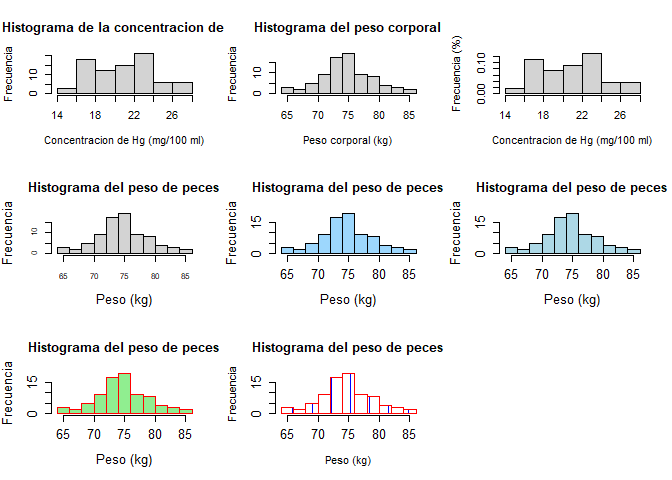

```r
#MEJORANDO EDICIONES
#Por ejemplo, podemos cambiar el nombre a los ejes (axes) y agregar un título.

# Configuramos el diseño de la disposición de los gráficos en 3 filas y 3 columnas
par(mfrow = c(3, 3))

# Creamos un histograma de la concentración de mercurio (Hg)
hist(dagraf$Hg,
     xlab = "Concentracion de Hg (mg/100 ml)", # Etiqueta del eje x
     ylab = "Frecuencia",                       # Etiqueta del eje y
     main = "Histograma de la concentracion de Hg") # Título del gráfico

# Creamos un histograma del peso corporal
hist(dagraf$peso,
     xlab = "Peso corporal (kg)",               # Etiqueta del eje x
     ylab = "Frecuencia",                       # Etiqueta del eje y
     main = "Histograma del peso corporal")     # Título del gráfico

# Creamos un histograma de la concentración de mercurio (Hg) sin mostrar la frecuencia relativa
hist(dagraf$Hg,
     xlab = "Concentracion de Hg (mg/100 ml)", # Etiqueta del eje x
     ylab = "Frecuencia (%)",                   # Etiqueta del eje y
     main = "",                                  # No se muestra título del gráfico
     freq = FALSE)                               # No mostrar frecuencia relativa

# Creamos un histograma del peso de peces con ajustes adicionales
hist(dagraf$peso,
     xlab = "Peso (kg)",                        # Etiqueta del eje x
     ylab = "Frecuencia",                       # Etiqueta del eje y
     main = "Histograma del peso de peces",     # Título del gráfico
     freq = TRUE,                                # Mostrar frecuencia absoluta
     cex.axis = 0.8,                             # Tamaño de las etiquetas de los ejes x e y
     cex.lab = 1.2)                              # Tamaño de las etiquetas de los ejes x e y

# Creamos un histograma del peso de peces con color personalizado
hist(dagraf$peso,
     xlab = "Peso (kg)",                        # Etiqueta del eje x
     ylab = "Frecuencia",                       # Etiqueta del eje y
     main = "Histograma del peso de peces",     # Título del gráfico
     freq = TRUE,                                # Mostrar frecuencia absoluta
     cex.axis = 1.2,                             # Tamaño de las etiquetas de los ejes x e y
     cex.lab = 1.2,                              # Tamaño de las etiquetas de los ejes x e y
     col = "#43B2FC85")                          # Color personalizado

# Creamos un histograma del peso de peces con color predefinido
hist(dagraf$peso,
     xlab = "Peso (kg)",                        # Etiqueta del eje x
     ylab = "Frecuencia",                       # Etiqueta del eje y
     main = "Histograma del peso de peces",     # Título del gráfico
     freq = TRUE,                                # Mostrar frecuencia absoluta
     cex.axis = 1.2,                             # Tamaño de las etiquetas de los ejes x e y
     cex.lab = 1.2,                              # Tamaño de las etiquetas de los ejes x e y
     col = "lightblue")                          # Color predefinido

# Creamos un histograma del peso de peces con color de fondo y borde personalizados
hist(dagraf$peso,
     xlab = "Peso (kg)",                        # Etiqueta del eje x
     ylab = "Frecuencia",                       # Etiqueta del eje y
     main = "Histograma del peso de peces",     # Título del gráfico
     freq = TRUE,                                # Mostrar frecuencia absoluta
     cex.axis = 1.2,                             # Tamaño de las etiquetas de los ejes x e y
     cex.lab = 1.2,                              # Tamaño de las etiquetas de los ejes x e y
     col = "#90EE90",                            # Color de fondo personalizado
     border = "red")                             # Color del borde personalizado

# Creamos un histograma del peso de peces con densidad y ángulo de inclinación personalizados
hist(dagraf$peso,
     xlab = "Peso (kg)",                        # Etiqueta del eje x
     ylab = "Frecuencia",                       # Etiqueta del eje y
     main = "Histograma del peso de peces",     # Título del gráfico
     freq = TRUE,                                # Mostrar frecuencia absoluta
     cex.axis = 1.2,                             # Tamaño de las etiquetas de
     col = "blue", border = "red", density = 5, angle = 90)

par(mfrow =c(1,1))
```